# Blunt-nosed Leopard Lizard Data Analysis: Climate at the Study Site

Savannah Weaver

# Packages

```r
knitr::opts_chunk$set(
    echo = TRUE,
    message = FALSE,
    warning = FALSE
)
`%nin%` = Negate(`%in%`)
if (!require("tidyverse")) install.packages("tidyverse")
library("tidyverse") # for dplyr workflow + ggplot
if (!require("weathermetrics")) install.packages("weathermetrics")
library("weathermetrics") # convert F to C
if (!require("RColorBrewer")) install.packages("RColorBrewer")
library("RColorBrewer") # plot colors
if (!require("ggpubr")) install.packages("ggpubr")
library("ggpubr") # for multi-ggplot figs
if (!require("rmdformats")) install.packages("rmdformats")
library("rmdformats") # clean html R markdown format
```

# Set Colors & Themes

```r
savs_ggplot_theme <- theme_classic() +
                     theme(text = element_text(color = "black",
                                               family = "sans",
                                               size = 12),
                           axis.text = element_text(color = "black",
                                                    family = "sans",
                                                    size = 8),
                           legend.text = element_text(color = "black",
                                                      family = "sans",
                                                      size = 8),
                           legend.text.align = 0,
                           legend.position = "bottom"
                           )
```

# Background & Introduction

# Load & Prep Data

## Sunrise & Sunset

These times were obtained from [NOAA ESRL](https://gml.noaa.gov/grad/solcalc/table.php?lat=35.304442&lon=-120.65925&year=2021).

All sunrise & set times during our study are with daylight savings time in effect (1 hour shift).

I only load in sunrise and sunset times for 2021, when we want to characterize the daytime versus nighttime local climate.

Sunrises:

```r
sunrises <- read.csv("./data/climate/Carrizo_sunrise_2021.csv")

sunrises_full <- sunrises %>%
  # put in tidy data format
  pivot_longer(
    cols = !Day,
    names_to = "month",
    values_to = "time"
  ) %>%
  # get rid of empty data
  dplyr::filter(time != "") %>%
  dplyr::filter(complete.cases(Day))

sunrises_formatted <- sunrises_full %>%
  mutate(date = as.POSIXct(paste("2021", month, Day, sep = "-"),
                           format = "%Y-%b-%d"),
         sunrise = as.POSIXct(paste(as.character(date), time, sep = " "))) %>%
  dplyr::select(-time, -Day, -month)
head(sunrises_formatted)
```

```
## # A tibble: 6 × 2
##   date                sunrise
##   <dttm>              <dttm>
## 1 2021-01-01 00:00:00 2021-01-01 07:08:00
## 2 2021-02-01 00:00:00 2021-02-01 06:58:00
## 3 2021-03-01 00:00:00 2021-03-01 06:28:00
## 4 2021-04-01 00:00:00 2021-04-01 06:46:00
## 5 2021-05-01 00:00:00 2021-05-01 06:08:00
## 6 2021-06-01 00:00:00 2021-06-01 05:46:00
```

Sunsets:

```r
sunsets <- read.csv("./data/climate/Carrizo_sunset_2021.csv")

sunsets_full <- sunsets %>%
  # put in tidy data format
  pivot_longer(
    cols = !Day,
    names_to = "month",
    values_to = "time"
  ) %>%
  # get rid of empty data
  dplyr::filter(time != "") %>%
  dplyr::filter(complete.cases(Day))

sunsets_formatted <- sunsets_full %>%
  mutate(date = as.POSIXct(paste("2021", month, Day, sep = "-"),
                           format = "%Y-%b-%d"),
         sunset = as.POSIXct(paste(as.character(date), time, sep = " "))) %>%
  dplyr::select(-time, -Day, -month)
head(sunsets_formatted)
```

```
## # A tibble: 6 × 2
##   date                sunset
##   <dttm>              <dttm>
## 1 2021-01-01 00:00:00 2021-01-01 16:59:00
## 2 2021-02-01 00:00:00 2021-02-01 17:28:00
## 3 2021-03-01 00:00:00 2021-03-01 17:55:00
## 4 2021-04-01 00:00:00 2021-04-01 19:21:00
## 5 2021-05-01 00:00:00 2021-05-01 19:46:00
## 6 2021-06-01 00:00:00 2021-06-01 20:09:00
```

## Burrows

All burrow data is with daylight savings time in effect (1 hour shift), so it will pair to the sunrise/sunset times correctly.

*Note: the burrow data comes from a much larger dataset, which I wrangle/prep in another Rproject/guthub repo*

variables in this dataframe, as named in the following summary:

- date_time = date and time temp/RH was logged
- date_only
- HOBO_ID = ID number for the burrow/data logger that the measurements come from
- temp_C = burrow microclimate temperature in degrees Celsius
- RH_percent = burrow relative humidity in percent
- VPD_kPa = burrow vapor pressure deficit in kilo-Pascals, calculated from the temperature and relative humidity values for each time using equations published by Campbell & Normal (1998)
- daytime = whether data is from daytime or nighttime, based on the sunrise and sunset times loaded above

### Load

```r
dat_HOBO <- read_rds("./data/climate/burrow_HOBOs_BNLL_activeszn_2021.RDS") %>%
  # add sunrise and sunset times
  left_join(sunrises_formatted, by = c('date_only' = 'date')) %>%
  left_join(sunsets_formatted, by = c('date_only' = 'date')) %>%
  # for each date, add whether that date_time is day or night
  group_by(date_only) %>%
  mutate(daytime = case_when(date_time_PST >= sunrise & date_time_PST <= sunset ~ "Day",
                             date_time_PST < sunrise ~ "Night",
                             date_time_PST > sunset ~ "Night"),
         daytime = as.factor(daytime)) %>%
  ungroup() %>%
  # select only variables of interest
  dplyr::select(date_time = date_time_PST,
                date_only, HOBO_ID,
                temp_C, RH_percent, VPD_kPa,
                daytime)

summary(dat_HOBO)
```

```
##    date_time                        date_only
##  Min.   :2021-04-26 03:00:00.00   Min.   :2021-04-26 00:00:00.00
##  1st Qu.:2021-05-14 05:00:00.00   1st Qu.:2021-05-14 00:00:00.00
##  Median :2021-06-06 00:00:00.00   Median :2021-06-05 00:00:00.00
##  Mean   :2021-06-04 22:31:27.63   Mean   :2021-06-04 07:46:25.07
##  3rd Qu.:2021-06-25 18:00:00.00   3rd Qu.:2021-06-25 00:00:00.00
##  Max.   :2021-07-14 02:30:00.00   Max.   :2021-07-13 00:00:00.00
##
##     HOBO_ID          temp_C        RH_percent       VPD_kPa
##  D      : 3792   Min.   :12.77   Min.   : 0.00   Min.   :0.003013
##  F      : 3792   1st Qu.:23.69   1st Qu.:29.93   1st Qu.:1.478705
##  G      : 3792   Median :27.28   Median :37.49   Median :2.282969
##  I      : 3792   Mean   :27.37   Mean   :43.16   Mean   :2.228349
##  J      : 3792   3rd Qu.:31.27   3rd Qu.:47.75   3rd Qu.:3.030895
##  K      : 3792   Max.   :41.92   Max.   :99.85   Max.   :7.423804
##  (Other):12518
##   daytime
##  Day  :20944
##  Night:14326
##
##
##
##
##
```

```r
head(dat_HOBO)
```

```
## # A tibble: 6 × 7
##   date_time           date_only           HOBO_ID temp_C RH_percent VPD_kPa
##   <dttm>              <dttm>              <fct>    <dbl>      <dbl>   <dbl>
## 1 2021-04-26 03:00:00 2021-04-26 00:00:00 C         18.6       99.7 0.00728
## 2 2021-04-26 03:30:00 2021-04-26 00:00:00 C         18.5       99.7 0.00704
## 3 2021-04-26 04:00:00 2021-04-26 00:00:00 C         18.6       99.7 0.00620
## 4 2021-04-26 04:30:00 2021-04-26 00:00:00 C         18.5       99.7 0.00640
## 5 2021-04-26 05:00:00 2021-04-26 00:00:00 C         18.5       99.7 0.00703
## 6 2021-04-26 05:30:00 2021-04-26 00:00:00 C         18.5       99.7 0.00637
## # ℹ 1 more variable: daytime <fct>
```

```r
length(unique(dat_HOBO$HOBO_ID)) # how many burrows did we log in?
```

```
## [1] 11
```

### Check Data

Throughout the time that I had HOBOs deployed in burrows, several loggers were chewed by mammals (probe broken), burrows were back-filled by kangaroo rats (and probes buried), or one burrow was completely excavated by kit foxes (probe was then logging aboveground microclimate). We will remove this data so that we only keep measurements taken from burrows that Blunt-nosed Leopard Lizards would typically be seen taking refuge in.

Check values for HOBOs: C, D, E, and L (*I didn’t create unique code for each thing*)

**HOBOs L and E** both broke mid-season, and were replaced June 10. To be safe, I will only keep the data for them after being re-deployed.

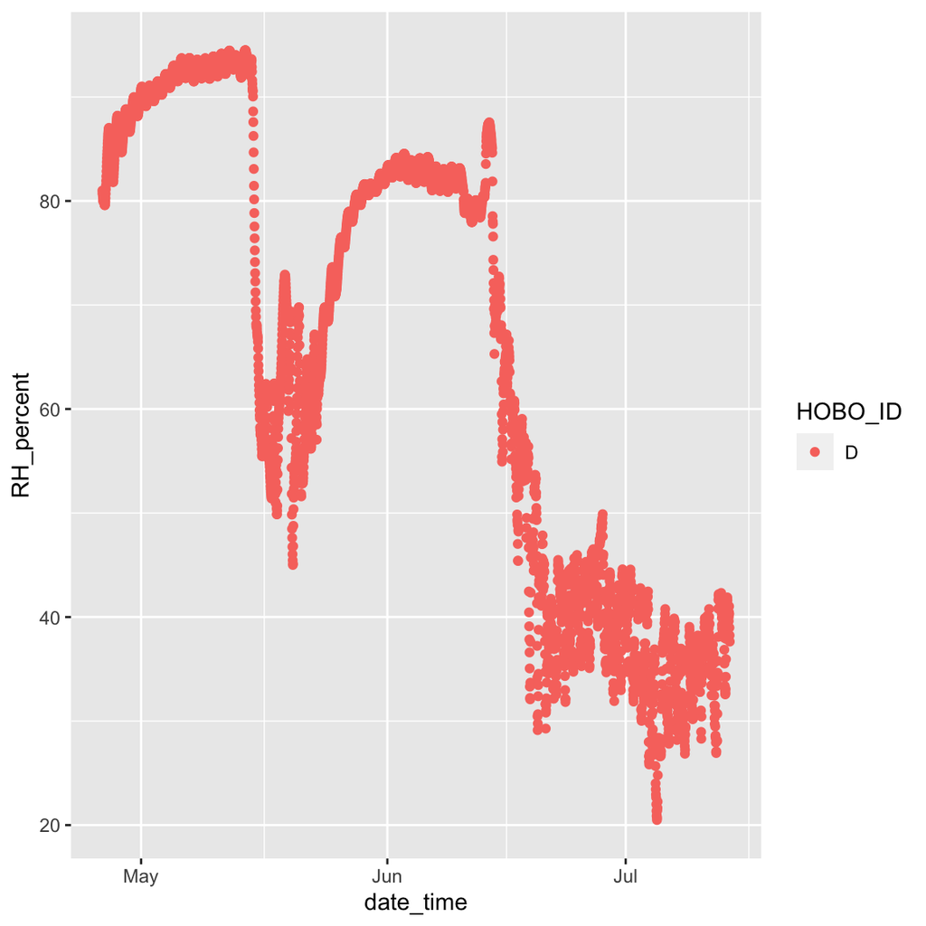

```r
dat_HOBO %>%
  dplyr::filter(HOBO_ID == "D") %>%
  ggplot(aes(
         x = date_time,
         y = RH_percent,
         color = HOBO_ID
       )) +
  geom_point()
```

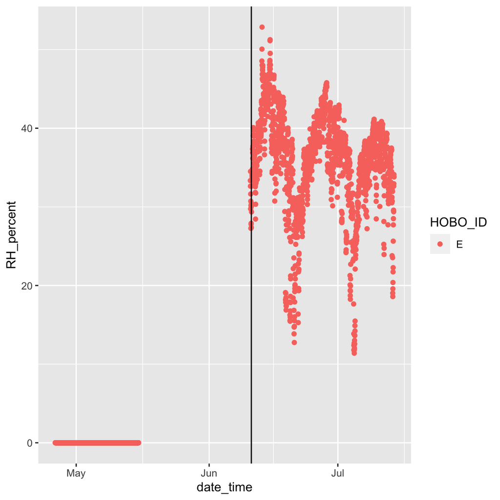

```r
dat_HOBO %>%
  dplyr::filter(HOBO_ID == "E") %>%
  ggplot(aes(
         x = date_time,
         y = RH_percent,
         #y = temp_C,
         color = HOBO_ID
       )) +
  geom_point() +
  geom_vline(xintercept = as.POSIXct("2021-06-10 20:00"))
```

### Clean

now, filter out:

```r
dat_HOBO_clean <- dat_HOBO %>%
  dplyr::filter(HOBO_ID != "C") %>%
  dplyr::filter(!(HOBO_ID == "L" & date_time < as.POSIXct("2021-06-10 20:00"))) %>%
  dplyr::filter(!(HOBO_ID == "E" & date_time < as.POSIXct("2021-06-10 20:00")))

# check
nrow(dat_HOBO_clean) + 731 + 944 + 278 == nrow(dat_HOBO)
```

```
## [1] TRUE
```

## Cochora Weather Station

This climate data was collected by a weather station 3.7 km due east of the study site: [Cochora Ranch, station ID: CXXC1](https://mesowest.utah.edu/cgi-bin/droman/meso_base_dyn.cgi?stn=CXXC1).

I download data from this weather station from Sept 2017 to Sept 2021 in order to look at precipitation trends over time. For the local temperature and humidity, I will only use 2021 data.

I had to download it from the website in 1-year chunks, and there is 1 hour of overlap between each sequential file, so I will have to fix that.

variables in this dataframe:

- Station_ID = the weather station ID, designated by the organization collecting the data
- date_time = date and time weather station (ws) logged data
- air_temp_F = local ambient temperature in degrees Fahrenheit
- RH_percent = local relative humidity in percent
- wind_speed_mph = local wind speed in miles per hour
- precip_accum_one_hour_inches = amount of precipitation accumulated by the weather station over the last hour, in inches; resets to zero every hour when the weather station records data
- date_only
- temp_C = local ambient temperature in degrees Celsius
- e_s_kPa = saturation vapor pressure deficit, an intermediate step to calculate VPD
- VPD_kPa = local vapor pressure deficit in kilo-Pascals, calculated from the temperature and relative humidity values for each time using equations published by Campbell & Normal (1998)

The weather station data is with daylight savings time in effect (1 hour shift), so it will pair with the burrow data correctly. :D

### Load

```r
# get all data
dat_ws <- read_csv("./data/climate/CXXC1_weather_2017to2018.csv") %>%
  rbind(read_csv("./data/climate/CXXC1_weather_2018to2019.csv")) %>%
  rbind(read_csv("./data/climate/CXXC1_weather_2019to2020.csv")) %>%
  rbind(read_csv("./data/climate/CXXC1_weather_2020to2021.csv"))

# pretty-fy
dat_ws_clean <- dat_ws %>%
  # remove repeat data rows
  distinct() %>%
  # only get variables of interest
  dplyr::select(Station_ID,
                date_time = Date_Time,
                air_temp_F,
                RH_percent = relative_humidity_percent,
                wind_speed_mph,
                precip_accum_one_hour_inches) %>%
  # remove rows with missing data
  dplyr::filter(complete.cases(air_temp_F, RH_percent)) %>%
  # format things
  mutate(date_time = as.POSIXct(date_time, format = "%m/%d/%Y %H:%M"),
         date_only = as.Date(substr(as.character(date_time), 1, 10),
                      format = "%Y-%m-%d"),
         temp_C = fahrenheit.to.celsius(air_temp_F, round = 2),
         # calculate vapor pressure deficit, Campbell & Normal 1998
         e_s_kPa = 0.611 * exp((17.502*temp_C)/(temp_C + 240.97)), # saturation VP
         # VPD
         VPD_kPa = e_s_kPa*(1 - (RH_percent/100))
         )

head(dat_ws_clean)
```

```
## # A tibble: 6 × 10
##   Station_ID date_time           air_temp_F RH_percent wind_speed_mph
##   <chr>      <dttm>                   <dbl>      <dbl>          <dbl>
## 1 CXXC1      2017-09-30 22:00:00       66.9         50           7.2
## 2 CXXC1      2017-09-30 23:00:00       65.5         52           4.9
## 3 CXXC1      2017-10-01 00:00:00       64.4         51           3.6
## 4 CXXC1      2017-10-01 01:00:00       63.3         58           3.8
## 5 CXXC1      2017-10-01 02:00:00       62.2         65           4.09
## 6 CXXC1      2017-10-01 03:00:00       62.6         67           6.2
## # ℹ 5 more variables: precip_accum_one_hour_inches <dbl>, date_only <date>,
## #   temp_C <dbl>, e_s_kPa <dbl>, VPD_kPa <dbl>
```

```r
summary(dat_ws_clean)
```

```
##   Station_ID          date_time                        air_temp_F
##  Length:34916       Min.   :2017-09-30 22:00:00.00   Min.   : 20.80
##  Class :character   1st Qu.:2018-09-30 01:45:00.00   1st Qu.: 50.50
##  Mode  :character   Median :2019-09-29 15:30:00.00   Median : 62.80
##                     Mean   :2019-09-30 20:02:12.27   Mean   : 65.08
##                     3rd Qu.:2020-09-30 17:15:00.00   3rd Qu.: 78.80
##                     Max.   :2021-09-30 22:00:00.00   Max.   :124.00
##
##    RH_percent     wind_speed_mph   precip_accum_one_hour_inches
##  Min.   :  3.00   Min.   : 0.000   Min.   :0.00000
##  1st Qu.: 29.00   1st Qu.: 2.800   1st Qu.:0.00000
##  Median : 43.00   Median : 4.700   Median :0.00000
##  Mean   : 48.44   Mean   : 5.142   Mean   :0.00075
##  3rd Qu.: 66.00   3rd Qu.: 7.000   3rd Qu.:0.00000
##  Max.   :100.00   Max.   :27.890   Max.   :0.37000
##                   NA's   :2        NA's   :152
##    date_only              temp_C         e_s_kPa           VPD_kPa
##  Min.   :2017-09-30   Min.   :-6.22   Min.   : 0.3843   Min.   :0.0000
##  1st Qu.:2018-09-30   1st Qu.:10.28   1st Qu.: 1.2504   1st Qu.:0.4403
##  Median :2019-09-29   Median :17.11   Median : 1.9497   Median :1.1526
##  Mean   :2019-09-30   Mean   :18.38   Mean   : 2.4832   Mean   :1.5077
##  3rd Qu.:2020-09-30   3rd Qu.:26.00   3rd Qu.: 3.3597   3rd Qu.:2.2110
##  Max.   :2021-09-30   Max.   :51.11   Max.   :13.0652   Max.   :8.6505
##
```

### Subset

Take a subset of weather station data only during our study to look at more closely:

```r
dat_ws_2021BNLL <- dat_ws_clean %>%
  # only during our study
  dplyr::filter(date_only > as.Date("2021-04-25") &
                  date_only < as.Date("2021-07-14")) %>%
  # add sunrise/set times
  left_join(sunrises_formatted, by = c('date_only' = 'date')) %>%
  left_join(sunsets_formatted, by = c('date_only' = 'date')) %>%
  group_by(date_only) %>%
  mutate(daytime = case_when(date_time >= sunrise & date_time <= sunset ~ "Day",
                             date_time < sunrise ~ "Night",
                             date_time > sunset ~ "Night"),
         daytime = as.factor(daytime)) %>%
  ungroup() %>%
  # select only relevant variables
  dplyr::select(date_time,
                date_only, Station_ID,
                temp_C, RH_percent, VPD_kPa, wind_speed_mph,
                daytime)

summary(dat_ws_2021BNLL)
```

```
##    date_time                     date_only           Station_ID
##  Min.   :2021-04-26 00:00:00   Min.   :2021-04-26   Length:1896
##  1st Qu.:2021-05-15 17:45:00   1st Qu.:2021-05-15   Class :character
##  Median :2021-06-04 11:30:00   Median :2021-06-04   Mode  :character
##  Mean   :2021-06-04 11:30:00   Mean   :2021-06-04
##  3rd Qu.:2021-06-24 05:15:00   3rd Qu.:2021-06-24
##  Max.   :2021-07-13 23:00:00   Max.   :2021-07-13
##      temp_C        RH_percent        VPD_kPa      wind_speed_mph    daytime
##  Min.   : 2.39   Min.   :  7.00   Min.   :0.000   Min.   : 0.300   Day  :1149
##  1st Qu.:19.57   1st Qu.: 22.00   1st Qu.:1.391   1st Qu.: 3.000   Night: 747
##  Median :25.61   Median : 30.00   Median :2.268   Median : 5.310
##  Mean   :25.30   Mean   : 33.97   Mean   :2.504   Mean   : 5.562
##  3rd Qu.:31.89   3rd Qu.: 42.00   3rd Qu.:3.458   3rd Qu.: 7.700
##  Max.   :45.00   Max.   :100.00   Max.   :7.294   Max.   :14.200
```

# Daily Means

Calculate daily mean temperature, humidity, and VPD for the weather station and each burrow where microclimate was recorded.

## Burrows

```r
dat_HOBO_means_by_burrow <- dat_HOBO_clean %>%
  # get daily means for each burrow/HOBO, for each date
  # I would consider this step averaging across technical replicates
  group_by(HOBO_ID, date_only, daytime # no diff for day vs night
           ) %>%
  summarise(temp_C_daily_mean_by_HOBO = mean(temp_C),
            RH_daily_mean_by_HOBO = mean(RH_percent),
            VPD_kPa_daily_mean_by_HOBO = mean(VPD_kPa)
            )
```

## Weather Station

```r
dat_ws_means <- dat_ws_2021BNLL %>%
  # get daily means for each date, daytime and nighttime
  # I would consider this step averaging across technical replicates
  group_by(date_only, daytime # only one WS, compared to multiple burrow loggers
           ) %>%
  summarise(temp_C_daily_mean = mean(temp_C),
            RH_daily_mean = mean(RH_percent),
            VPD_kPa_daily_mean = mean(VPD_kPa),
            wind_mph_mean = mean(wind_speed_mph)
            )
```

# Time Period Means

Now, use daily means to get means across different time periods throughout the G. sila active season that we studied. First, create the time periods:

```r
# capture weekend dates = don't want data for days we measured lizards
cap_dates <- as.Date(c("2021-04-23", "2021-04-24", "2021-04-25", # April
                        "2021-05-07", "2021-05-08", "2021-05-09"), # May
                     format = "%Y-%m-%d")

# grouping by date
# create an inclusive range of the desired dates
group_dates <- data.frame(date_only = c(seq(as.Date("2021-04-26"),
                                            as.Date("2021-07-13"), by = 1))) %>%
  # remove unwanted dates
  dplyr::filter(date_only %nin% cap_dates) %>%
  # add group labels for designated time periods
  mutate(date_chunks = factor(c(rep("Apr 26 - May 6", 11),
                                rep("May 10 - 20", 11),
                                rep("May 21 - 31", 11),
                                rep("Jun 1 - 11", 11),
                                rep("Jun 12 - 22", 11),
                                rep("Jun 23 - Jul 3", 11),
                                rep("Jul 4 - 13", 10)),
                              levels = c("Apr 26 - May 6", "May 10 - 20",
                                         "May 21 - 31", "Jun 1 - 11", "Jun 12 - 22",
                                         "Jun 23 - Jul 3", "Jul 4 - 13")))

summary(group_dates)
```

```
##    date_only                  date_chunks
##  Min.   :2021-04-26   Apr 26 - May 6:11
##  1st Qu.:2021-05-17   May 10 - 20   :11
##  Median :2021-06-05   May 21 - 31   :11
##  Mean   :2021-06-05   Jun 1 - 11    :11
##  3rd Qu.:2021-06-24   Jun 12 - 22   :11
##  Max.   :2021-07-13   Jun 23 - Jul 3:11
##                       Jul 4 - 13    :10
```

## Burrows

Join time periods & daily mean burrow data, then get the mean daily temps for each time period:

```r
dat_HOBO_chunks_by_burrow <- dat_HOBO_means_by_burrow %>%
  # add time periods
  left_join(group_dates, by = 'date_only') %>%
  # remove NA values for time periods (data on capture days, just for consistency)
  dplyr::filter(complete.cases(date_chunks)) %>%
  # get avg across days within a time periods for each HOBO/burrow
  group_by(HOBO_ID, date_chunks, daytime
           ) %>%
  # get the avg daily mean for each time period for each burrow
  summarise(temp_C_chunk_mean_by_HOBO = mean(temp_C_daily_mean_by_HOBO),
            RH_chunk_mean_by_HOBO = mean(RH_daily_mean_by_HOBO),
            VPD_kPa_chunk_mean_by_HOBO = mean(VPD_kPa_daily_mean_by_HOBO),
            # how many days were successfully logged per time period per burrow?
            n = n()
            ) %>%
  # only use time periods for burrows with at least 3 days logged for that time period
  # removes 6 values
  dplyr::filter(n >= 3) %>%
  arrange(HOBO_ID, date_chunks)
```

and then, means across burrows for each time chunk:

```r
dat_HOBO_chunk_means <- dat_HOBO_chunks_by_burrow %>%
  # get avg across days within a time periods for each daytime and nighttime
  group_by(date_chunks, daytime
           ) %>%
  # get the avg daily mean, min, and max per time period
  summarise(temp_C_chunk_mean = mean(temp_C_chunk_mean_by_HOBO),
            temp_C_chunk_min = min(temp_C_chunk_mean_by_HOBO),
            temp_C_chunk_max = max(temp_C_chunk_mean_by_HOBO),
            RH_chunk_mean = mean(RH_chunk_mean_by_HOBO),
            RH_chunk_min = min(RH_chunk_mean_by_HOBO),
            RH_chunk_max = max(RH_chunk_mean_by_HOBO),
            VPD_kPa_chunk_mean = mean(VPD_kPa_chunk_mean_by_HOBO),
            VPD_kPa_chunk_min = min(VPD_kPa_chunk_mean_by_HOBO),
            VPD_kPa_chunk_max = max(VPD_kPa_chunk_mean_by_HOBO),
            n = n()
            ) %>%
  mutate(logger = "Burrow")

summary(dat_HOBO_chunk_means)
```

```
##          date_chunks  daytime  temp_C_chunk_mean temp_C_chunk_min
##  Apr 26 - May 6:2    Day  :7   Min.   :21.04     Min.   :18.59
##  May 10 - 20   :2    Night:7   1st Qu.:24.64     1st Qu.:21.51
##  May 21 - 31   :2              Median :27.84     Median :24.53
##  Jun 1 - 11    :2              Mean   :27.72     Mean   :24.73
##  Jun 12 - 22   :2              3rd Qu.:30.87     3rd Qu.:28.14
##  Jun 23 - Jul 3:2              Max.   :34.18     Max.   :30.80
##  Jul 4 - 13    :2
##  temp_C_chunk_max RH_chunk_mean    RH_chunk_min    RH_chunk_max
##  Min.   :22.10    Min.   :30.51   Min.   :21.41   Min.   :39.12
##  1st Qu.:25.80    1st Qu.:34.99   1st Qu.:26.31   1st Qu.:44.18
##  Median :29.46    Median :44.66   Median :27.44   Median :82.40
##  Mean   :29.37    Mean   :43.68   Mean   :28.52   Mean   :71.14
##  3rd Qu.:32.41    3rd Qu.:49.57   3rd Qu.:29.89   3rd Qu.:92.60
##  Max.   :36.91    Max.   :61.39   Max.   :41.30   Max.   :96.39
##
##  VPD_kPa_chunk_mean VPD_kPa_chunk_min VPD_kPa_chunk_max       n
##  Min.   :0.9997     Min.   :0.09942   Min.   :1.669     Min.   : 8.000
##  1st Qu.:1.5374     1st Qu.:0.24324   1st Qu.:2.313     1st Qu.: 8.000
##  Median :2.0656     Median :0.70900   Median :2.779     Median : 8.000
##  Mean   :2.2540     Mean   :1.25079   Mean   :2.942     Mean   : 8.857
##  3rd Qu.:2.9411     3rd Qu.:2.27057   3rd Qu.:3.600     3rd Qu.:10.000
##  Max.   :3.7646     Max.   :3.08153   Max.   :4.455     Max.   :10.000
##
##     logger
##  Length:14
##  Class :character
##  Mode  :character
##
##
##
##
```

## Weather Station

Join time periods & daily mean local weather station data, then get the mean daily temps for each time period:

```r
dat_ws_chunk_means <- dat_ws_means %>%
  # add time periods
  left_join(group_dates, by = 'date_only') %>%
  # remove NA values for time periods (data on capture days, just for consistency)
  dplyr::filter(complete.cases(date_chunks)) %>%
  # get avg across days within a time periods for each daytime and nighttime
  group_by(date_chunks, daytime
           ) %>%
  # get the avg daily mean per time period
  summarise(temp_C_chunk_mean = mean(temp_C_daily_mean),
            temp_C_chunk_min = min(temp_C_daily_mean),
            temp_C_chunk_max = max(temp_C_daily_mean),
            RH_chunk_mean = mean(RH_daily_mean),
            RH_chunk_min = min(RH_daily_mean),
            RH_chunk_max = max(RH_daily_mean),
            VPD_kPa_chunk_mean = mean(VPD_kPa_daily_mean),
            VPD_kPa_chunk_min = min(VPD_kPa_daily_mean),
            VPD_kPa_chunk_max = max(VPD_kPa_daily_mean),
            wind_speed_mph_chunk_mean = mean(wind_mph_mean),
            n = n()
            ) %>%
  mutate(logger = "Aboveground")

summary(dat_ws_chunk_means)
```

```
##          date_chunks  daytime  temp_C_chunk_mean temp_C_chunk_min
##  Apr 26 - May 6:2    Day  :7   Min.   :17.22     Min.   : 8.273
##  May 10 - 20   :2    Night:7   1st Qu.:21.21     1st Qu.:11.600
##  May 21 - 31   :2              Median :24.89     Median :14.354
##  Jun 1 - 11    :2              Mean   :25.21     Mean   :17.458
##  Jun 12 - 22   :2              3rd Qu.:29.52     3rd Qu.:22.776
##  Jun 23 - Jul 3:2              Max.   :34.51     Max.   :30.833
##  Jul 4 - 13    :2
##  temp_C_chunk_max RH_chunk_mean    RH_chunk_min    RH_chunk_max
##  Min.   :22.46    Min.   :21.74   Min.   :15.07   Min.   :31.89
##  1st Qu.:27.30    1st Qu.:31.92   1st Qu.:18.47   1st Qu.:45.32
##  Median :30.51    Median :34.08   Median :20.14   Median :55.94
##  Mean   :30.60    Mean   :34.41   Mean   :21.43   Mean   :56.33
##  3rd Qu.:34.45    3rd Qu.:39.19   3rd Qu.:24.15   3rd Qu.:65.74
##  Max.   :38.41    Max.   :44.19   Max.   :29.89   Max.   :84.08
##
##  VPD_kPa_chunk_mean VPD_kPa_chunk_min VPD_kPa_chunk_max
##  Min.   :1.364      Min.   :0.2113    Min.   :2.107
##  1st Qu.:1.872      1st Qu.:0.6721    1st Qu.:2.923
##  Median :2.372      Median :1.1689    Median :3.322
##  Mean   :2.471      Mean   :1.3216    Mean   :3.545
##  3rd Qu.:3.133      3rd Qu.:1.7518    3rd Qu.:4.123
##  Max.   :4.487      Max.   :3.2876    Max.   :5.850
##
##  wind_speed_mph_chunk_mean       n            logger
##  Min.   :4.048             Min.   :10.00   Length:14
##  1st Qu.:4.632             1st Qu.:11.00   Class :character
##  Median :5.358             Median :11.00   Mode  :character
##  Mean   :5.353             Mean   :10.86
##  3rd Qu.:5.944             3rd Qu.:11.00
##  Max.   :6.882             Max.   :11.00
##
```

## Join WS & HOBO Data

```r
all_clim_dat <- dat_ws_chunk_means %>%
  dplyr::select(-wind_speed_mph_chunk_mean) %>%
  rbind(dat_HOBO_chunk_means) %>%
  mutate(logger_daytime = factor(paste(logger, daytime, sep = " "),
                         levels = c("Burrow Day",
                                    "Aboveground Day",
                                    "Burrow Night",
                                    "Aboveground Night")),
         logger = factor(logger
                         ))

summary(all_clim_dat)
```

```
##          date_chunks  daytime   temp_C_chunk_mean temp_C_chunk_min
##  Apr 26 - May 6:4    Day  :14   Min.   :17.22     Min.   : 8.273
##  May 10 - 20   :4    Night:14   1st Qu.:22.19     1st Qu.:14.899
##  May 21 - 31   :4               Median :26.44     Median :21.680
##  Jun 1 - 11    :4               Mean   :26.47     Mean   :21.095
##  Jun 12 - 22   :4               3rd Qu.:30.57     3rd Qu.:27.588
##  Jun 23 - Jul 3:4               Max.   :34.51     Max.   :30.833
##  Jul 4 - 13    :4
##  temp_C_chunk_max RH_chunk_mean    RH_chunk_min    RH_chunk_max
##  Min.   :22.10    Min.   :21.74   Min.   :15.07   Min.   :31.89
##  1st Qu.:26.81    1st Qu.:33.91   1st Qu.:20.20   1st Qu.:44.83
##  Median :30.19    Median :35.57   Median :25.46   Median :57.64
##  Mean   :29.99    Mean   :39.04   Mean   :24.98   Mean   :63.74
##  3rd Qu.:33.06    3rd Qu.:44.43   3rd Qu.:27.67   3rd Qu.:83.23
##  Max.   :38.41    Max.   :61.39   Max.   :41.30   Max.   :96.39
##
##  VPD_kPa_chunk_mean VPD_kPa_chunk_min VPD_kPa_chunk_max       n
##  Min.   :0.9997     Min.   :0.09942   Min.   :1.669     Min.   : 8.000
##  1st Qu.:1.6342     1st Qu.:0.36753   1st Qu.:2.361     1st Qu.: 8.000
##  Median :2.2465     Median :1.02123   Median :3.199     Median :10.000
##  Mean   :2.3627     Mean   :1.28621   Mean   :3.243     Mean   : 9.857
##  3rd Qu.:3.0268     3rd Qu.:2.05425   3rd Qu.:3.859     3rd Qu.:11.000
##  Max.   :4.4872     Max.   :3.28761   Max.   :5.850     Max.   :11.000
##
##          logger             logger_daytime
##  Aboveground:14   Burrow Day       :7
##  Burrow     :14   Aboveground Day  :7
##                   Burrow Night     :7
##                   Aboveground Night:7
##
##
##
```

# Figures

## Temperature

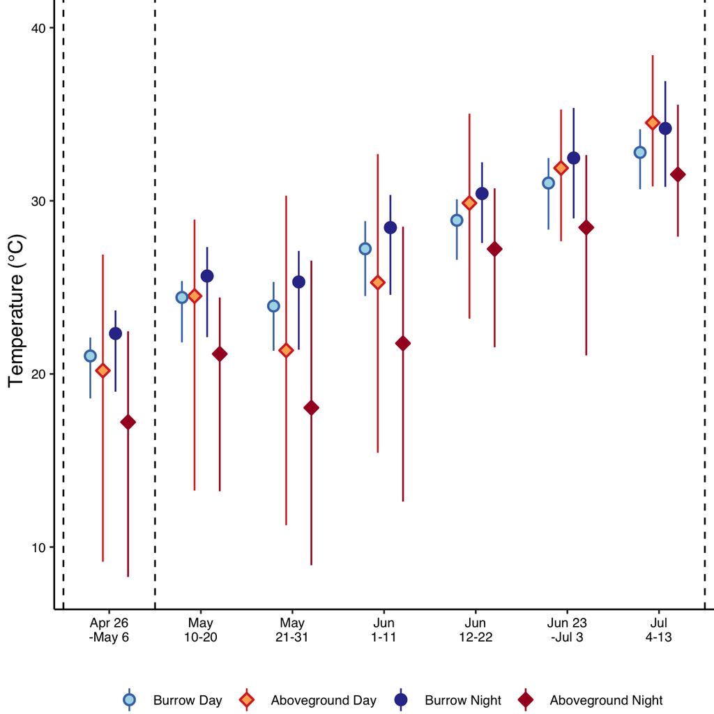

```r
ggplot(data = all_clim_dat) +
  geom_pointrange(
    aes(
      x = (date_chunks),
      y = temp_C_chunk_mean,
      ymin = temp_C_chunk_min,
      ymax = temp_C_chunk_max,
      group = logger_daytime,
      color = logger_daytime,
      fill = logger_daytime,
      shape = logger_daytime
    ),
    position = position_dodge(width = 0.55),
    alpha = 1,
    size = 0.6
  ) +
  labs(y = "Temperature (°C)  ") +
  scale_x_discrete(labels = c("Apr 26\n-May 6",
                              "May\n10-20",
                              "May\n21-31",
                              "Jun\n1-11",
                              "Jun\n12-22",
                              "Jun 23\n-Jul 3",
                              "Jul\n4-13"
                              ),
                   name = "") +
  # lines to show when we took hydric physiology measurements
  geom_vline(xintercept = 0.5,
             linetype = "dashed",
             size = 0.5) +
  geom_vline(xintercept = 1.5,
             linetype = "dashed",
             size = 0.5) +
  geom_vline(xintercept = 7.5,
             linetype = "dashed",
             size = 0.5) +
  # pretty-fy
  scale_fill_manual(values = c(brewer.pal(11, "RdYlBu")[c(8, 4, 11, 1)]), name = NULL) +
  scale_shape_manual(values = c(21, 23, 21, 23), name = NULL) +
  scale_color_manual(values = c(brewer.pal(11, "RdYlBu")[c(10, 2, 11, 1)]), name = NULL) +
  # additional formatting
  ylim(8, 40) +
  # guides(shape = guide_legend(nrow = 2),
  #        fill = guide_legend(nrow = 2)) +
  savs_ggplot_theme +
  theme(plot.margin = margin(t = 0, r = 0, b = 0, l = 5,
                             unit = "pt"),
        legend.margin = margin(0,0,0,0, unit = "pt")
        ) -> daily_temps_fig
daily_temps_fig
```

```r
ggsave(filename = "climate_temp_standalone.pdf",
       plot = daily_temps_fig,
       path = "./results_figures",
       device = "pdf",
       dpi = 600,
       units = "mm",
       width = 130, height = 100
       )
```

## Relative Humidity

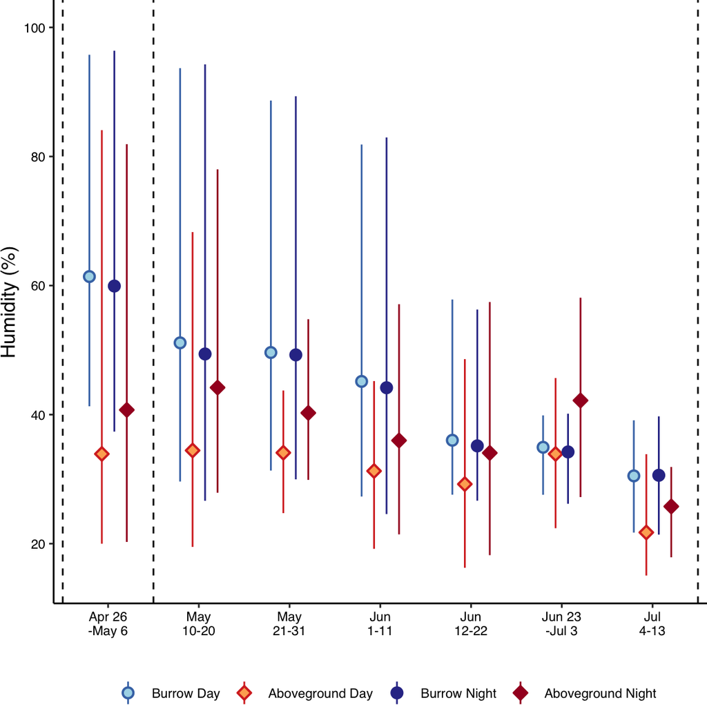

```r
ggplot(data = all_clim_dat) +
  geom_pointrange(
    aes(
      x = (date_chunks),
      y = RH_chunk_mean,
      ymin = RH_chunk_min,
      ymax = RH_chunk_max,
      group = logger_daytime,
      color = logger_daytime,
      fill = logger_daytime,
      shape = logger_daytime
    ),
    position = position_dodge(width = 0.55),
    alpha = 1,
    size = 0.6
  ) +
  labs(y = "Humidity (%)") +
  scale_x_discrete(labels = c("Apr 26\n-May 6",
                              "May\n10-20",
                              "May\n21-31",
                              "Jun\n1-11",
                              "Jun\n12-22",
                              "Jun 23\n-Jul 3",
                              "Jul\n4-13"
                              ),
                   name = "") +
  # lines to show when we took hydric physiology measurements
  geom_vline(xintercept = 0.5,
             linetype = "dashed",
             size = 0.5) +
  geom_vline(xintercept = 1.5,
             linetype = "dashed",
             size = 0.5) +
  geom_vline(xintercept = 7.5,
             linetype = "dashed",
             size = 0.5) +
  # pretty-fy
  scale_fill_manual(values = c(brewer.pal(11, "RdYlBu")[c(8, 4, 11, 1)]), name = NULL) +
  scale_shape_manual(values = c(21, 23, 21, 23), name = NULL) +
  scale_color_manual(values = c(brewer.pal(11, "RdYlBu")[c(10, 2, 11, 1)]), name = NULL) +
  # additional formatting
  scale_y_continuous(limits = c(15, 100),
                     breaks = c(seq(0, 100, 20)),
                     labels = c(seq(0, 100, 20))) +
  # guides(shape = guide_legend(nrow = 2),
  #        fill = guide_legend(nrow = 2)) +
  savs_ggplot_theme +
  theme(plot.margin = margin(t = 0, r = 0, b = 0, l = 0.5,
                             unit = "pt"),
        legend.margin = margin(0,0,0,0, unit = "pt")
        ) -> daily_RH_fig
daily_RH_fig
```

## Vapor Pressure Deficit

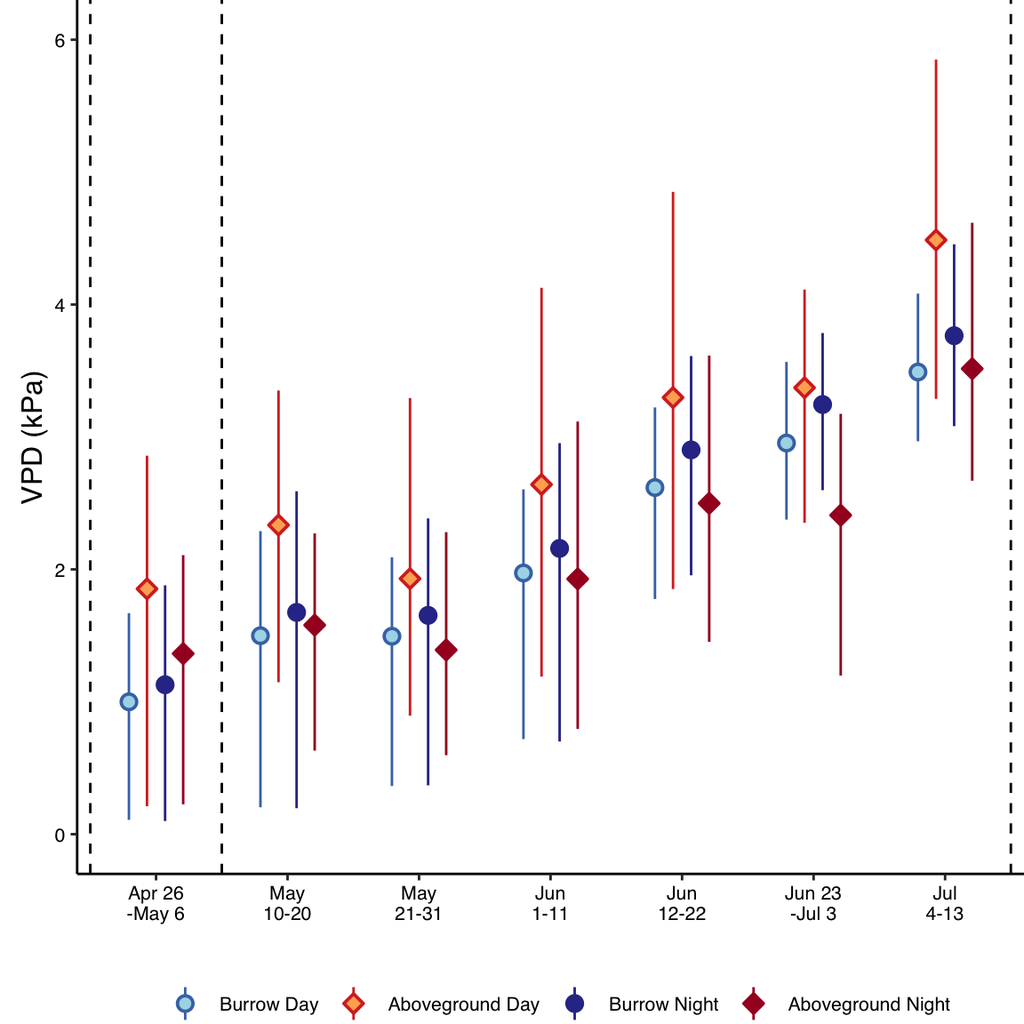

```r
ggplot(data = all_clim_dat) +
  geom_pointrange(
    aes(
      x = date_chunks,
      y = VPD_kPa_chunk_mean,
      ymin = VPD_kPa_chunk_min,
      ymax = VPD_kPa_chunk_max,
      group = logger_daytime,
      color = logger_daytime,
      fill = logger_daytime,
      shape = logger_daytime
    ),
    position = position_dodge(width = 0.55),
    alpha = 1,
    size = 0.6
  ) +
  labs(y = "VPD (kPa)") +
  scale_x_discrete(labels = c("Apr 26\n-May 6",
                              "May\n10-20",
                              "May\n21-31",
                              "Jun\n1-11",
                              "Jun\n12-22",
                              "Jun 23\n-Jul 3",
                              "Jul\n4-13"
                              ),
                   name = "") +
  # lines to show when we took hydric physiology measurements
  geom_vline(xintercept = 0.5,
             linetype = "dashed",
             size = 0.5) +
  geom_vline(xintercept = 1.5,
             linetype = "dashed",
             size = 0.5) +
  geom_vline(xintercept = 7.5,
             linetype = "dashed",
             size = 0.5) +
  # pretty-fy
  scale_fill_manual(values = c(brewer.pal(11, "RdYlBu")[c(8, 4, 11, 1)]), name = NULL) +
  scale_shape_manual(values = c(21, 23, 21, 23), name = NULL) +
  scale_color_manual(values = c(brewer.pal(11, "RdYlBu")[c(10, 2, 11, 1)]), name = NULL) +
  # additional formatting
  scale_y_continuous(limits = c(0, 6),
                     breaks = c(seq(0, 6, 2)),
                     labels = c(seq(0, 6, 2))) +
  # guides(shape = guide_legend(nrow = 2),
  #        fill = guide_legend(nrow = 2)) +
  savs_ggplot_theme +
  theme(plot.margin = margin(t = 0, r = 0, b = 0, l = 9.2,
                             unit = "pt"),
        legend.margin = margin(0,0,0,0, unit = "pt")
        ) -> daily_VPD_fig
daily_VPD_fig
```

## Wind

This data is only from the weather station

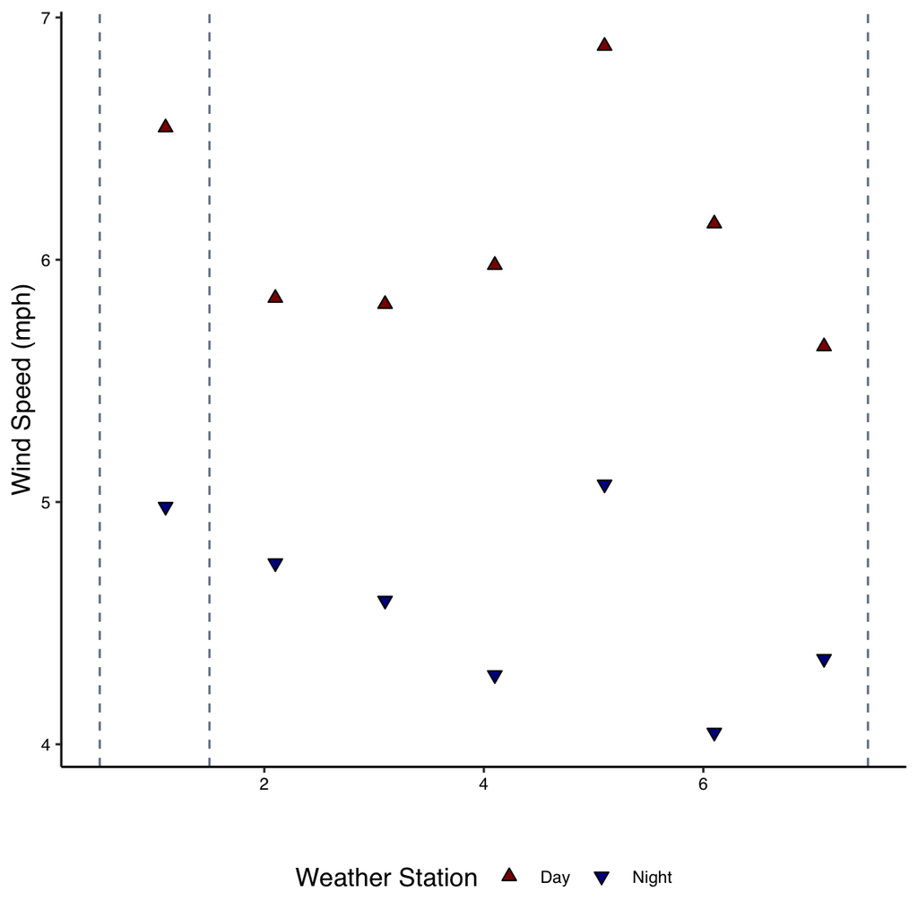

```r
ggplot() +
  geom_point(data = dat_ws_chunk_means,
             aes(x = as.numeric(date_chunks)+0.1,
                 y = wind_speed_mph_chunk_mean,
                 fill = daytime,
                 shape = daytime
                 ),
             alpha = 1,
             size = 2) +
  xlab("") +
  ylab("Wind Speed (mph)") +
  # lines to show when we took hydric physiology measurements
  geom_vline(xintercept = 0.5, #as.Date("2021-04-25"),
             linetype = "dashed",
             color = "slategray") +
  geom_vline(xintercept = 1.5, #as.Date("2021-05-08"),
             linetype = "dashed",
             color = "slategray") +
  geom_vline(xintercept = 7.5, #as.Date("2021-07-14"),
             linetype = "dashed",
             color = "slategray") +
  scale_fill_manual(values = c("darkred", "darkblue"), name = "Weather Station"
                     ) +
  scale_shape_manual(values = 24:25, name = "Weather Station"
                     ) +
  savs_ggplot_theme -> daily_wind_fig
daily_wind_fig
```

# Export Multi-Figure

Put the temperature, RH, and VPD figures arranged into one for publication.

```r
daily_temps_fig_multi <- daily_temps_fig +
  theme(axis.text.x = element_blank(),
        axis.ticks.x = element_blank())
daily_RH_fig_multi <- daily_RH_fig +
  theme(axis.text.x = element_blank(),
        axis.ticks.x = element_blank())


ggarrange(daily_temps_fig_multi, daily_RH_fig_multi, daily_VPD_fig,
          ncol = 1, nrow = 3,
          labels = c("(a)", "(b)", "(c)"),
          label.y = 1.02,
          label.x = -0.01,
          font.label = list(color = "black", face = "bold", size = 10),
          heights = c(1, 1, 1.11),
          common.legend = TRUE,
          legend = "bottom"
          ) -> multi_climate

ggsave(filename = "climate_multi_figure_vertical.pdf",
       plot = multi_climate,
       path = "./results_figures",
       device = "pdf",
       dpi = 600,
       units = "mm",
       width = 160, height = 150
       )
```

# Across Years

In addition to looking at how climate changed throughout the G. sila active season of our study, we also want to quantify the local rainfall to help provide evidence for the drought during our study.

## Prep Data

I am defining winter as Dec to March. We will look at precipitation in this time period each year for our study year and the 3 years prior.

```r
dat_ws_compare_years <- dat_ws_clean %>%
  # add a variable for the "year" of the winter period, since it technically spans years
  mutate(year = case_when(date_only >= as.Date("2017-12-01") &
                            date_only < as.Date("2018-03-30") ~ 2018,
                          date_only >= as.Date("2018-12-01") &
                            date_only < as.Date("2019-03-30") ~ 2019,
                          date_only >= as.Date("2019-12-01") &
                            date_only < as.Date("2020-03-30") ~ 2020,
                          date_only >= as.Date("2020-12-01") &
                            date_only < as.Date("2021-03-30") ~ 2021),
         year = factor(year)) %>%
  dplyr::filter(complete.cases(year))

summary(dat_ws_compare_years)
```

```
##   Station_ID          date_time                        air_temp_F
##  Length:11385       Min.   :2017-12-01 00:00:00.00   Min.   :27.90
##  Class :character   1st Qu.:2018-03-29 16:00:00.00   1st Qu.:43.20
##  Mode  :character   Median :2019-03-29 19:00:00.00   Median :48.60
##                     Mean   :2019-07-30 11:31:34.06   Mean   :49.18
##                     3rd Qu.:2020-03-29 05:00:00.00   3rd Qu.:54.70
##                     Max.   :2021-03-29 23:00:00.00   Max.   :78.60
##
##    RH_percent     wind_speed_mph   precip_accum_one_hour_inches
##  Min.   :  4.00   Min.   : 0.000   Min.   :0.00000
##  1st Qu.: 41.00   1st Qu.: 2.800   1st Qu.:0.00000
##  Median : 63.00   Median : 4.410   Median :0.00000
##  Mean   : 61.47   Mean   : 5.112   Mean   :0.00167
##  3rd Qu.: 84.00   3rd Qu.: 6.700   3rd Qu.:0.00000
##  Max.   :100.00   Max.   :27.890   Max.   :0.37000
##                                    NA's   :57
##    date_only              temp_C          e_s_kPa          VPD_kPa
##  Min.   :2017-12-01   Min.   :-2.280   Min.   :0.5169   Min.   :0.0000
##  1st Qu.:2018-03-29   1st Qu.: 6.220   1st Qu.:0.9491   1st Qu.:0.1609
##  Median :2019-03-29   Median : 9.220   Median :1.1645   Median :0.4204
##  Mean   :2019-07-29   Mean   : 9.543   Mean   :1.2438   Mean   :0.5468
##  3rd Qu.:2020-03-29   3rd Qu.:12.610   3rd Qu.:1.4589   3rd Qu.:0.8024
##  Max.   :2021-03-29   Max.   :25.890   Max.   :3.3379   Max.   :2.9707
##
##    year
##  2018:2854
##  2019:2843
##  2020:2860
##  2021:2828
##
##
##
```

## Mean Precip Per Year

What was the cumulative amount of rain for each winter?

```r
cum_rain <- dat_ws_compare_years %>%
  group_by(year) %>%
  summarise(winter_precip_in = sum(precip_accum_one_hour_inches, na.rm = TRUE)) %>%
  mutate(winter_precip_mm = winter_precip_in*25.4)
cum_rain
```

```
## # A tibble: 4 × 3
##   year  winter_precip_in winter_precip_mm
##   <fct>            <dbl>            <dbl>
## 1 2018              3.89             98.8
## 2 2019              7.61            193.
## 3 2020              4.5             114.
## 4 2021              2.91             73.9
```

```r
prior_mean_in <- cum_rain %>%
  dplyr::filter(year != 2021) %>%
  summarise(mean(winter_precip_in))

prior_mean_mm <- cum_rain %>%
  dplyr::filter(year != 2021) %>%
  summarise(mean(winter_precip_mm))

2.91/prior_mean_in # inches
```

```
##   mean(winter_precip_in)
## 1               0.545625
```

```r
73.914/prior_mean_mm #mm (same prop)
```

```
##   mean(winter_precip_mm)
## 1               0.545625
```

Precipitation in 2021, our study year, was ~50% that of the previous 3-year average.